# Stochastic Calculus I

Alexander Kaier, Christoph Richard

2025-10-30

# 1 Introduction

Last time, you have learned how to use R as a basic calculator, you got to know some important data types like vectors and data frames, learned how to load data into R and got into first contact with the amazing tidyverse.

Today, you will learn how you can do simulate stochastic processes in R. This will help you deepen your understanding of the lectures on stochastics. It will also help understand the mathematics that we will encounter in future lectures and courses.

# 2 Discrete random variables

As in the lecture, we assume that a discrete random variable (RV) only attains at most countably many integer values with positive probabilities. Now we consider two very important concepts regarding RVs, namely expectation and variance. You know these concepts from high school, where you have considered experiments with finitely many outcomes.

However, before we dive into expectation and variance, we will take a look at a very useful function in R, namely `sample()`. This function allows you to draw random samples from a given set of outcomes. For example, if we want to simulate the roll of a fair six-sided die, we can use the following code:

```r
# Simulate rolling a fair six-sided die
sample(1:6, size = 10, replace = TRUE)
```

```
##  [1] 6 3 2 2 3 2 5 1 3 3
```

We used `replace=TRUE` because after you throw a die, the side usually can be thrown again and is not “used up”. You know this concept from school and from lectures as “drawing with replacement”.

It is also possible to explicitly define the probabilities for each possible outcome. For example, a loaded die that shows a 6 with probability 0.5 and all other sides with probability 0.1 can be simulated like this:

```r
sample(1:6,prob=c(rep(1/10, 5),1/2),replace=TRUE, size = 10)
```

```
##  [1] 4 6 3 6 1 6 3 4 6 1
```

## 2.1 Expectation

If we play a gamble where certain outcomes are associated with different payoffs that can be made, we might ask the very reasonable question how much we are willing to pay as playing fee while not making any loss in the long run when playing many times.

If the gamble is described by a random variable $X$, then the above question can be answered by the *expectation* $\mathbb{E}[X]$ of $X$. As shown in the lecture, the formula for the expectation is $\mathbb{E}[X] = \sum_{k\in\mathbb{Z}} k\cdot p_k$, where $p_k = \mathbb{P}[X=k]$. The expectation is a weighted sum of all possible outcomes of the RV, where each outcome contributes proportionally to the probability by which it is observed.

But why does the expectation describe your playing fee? We reason is that, when repeating the gamble independently many times, the average outcome will be close to the expectation. We will simulate this fundamental observation below. A mathematical formulation of this observation is the so-called strong law of large numbers.

Here is an example:

- When throwing a fair die once, we have outcomes $1,2,3,4,5,6$ with equal probabilities. This can be described by an integer-valued random variable $X$ where $\mathbb{P}[X=k]=\frac{1}{6}$ for $k = 1,...,6$ and $\mathbb{P}[X=k]=0$ for all other $k$. The expectation is in this case:

$$\mathbb{E}[X]=\sum p_k\cdot
k=\frac{1}{6}\cdot1+\cdot\cdot\cdot+\frac{1}{6}\cdot6=3.5$$

Now this is an interesting result. If someone offered us a gamble where a single dice is thrown once and we get as prize the value that is shown after we pay a fee, this is how much we should be willing to pay at most for each game. Every fee below 3.5 Euro will give us the difference as profit if we play many games. At exactly 3.5 Euro there is nothing to be gained or lost on average, and for every fee over 3.5 Euro you will soon start to regret not having studied stochastic sooner.

Thinking about gambling, wins and losses is not just a good starting point for us when trying to understand stochastic principles. The whole field was actually invented by Italian polymath Gerolamo Cardano, who wrote *‘Liber de Ludo Aleae’* (“Book on Games of Chance”) in the 16th century. The book discusses in great detail probabilities in dice games. Besides his thoughts about games of chance, Cardano also wrote *‘Ars magna’*, which contained the first ever systematic use of negative numbers as well as solution to cubic and quartic equations. It also deals with imaginary numbers, which were at this point still unknown to the mathematical community.

We can even weave the fee explicitly into the RV itself by defining $Y = X - f$, where $f$ describes the fee we pay. Now $Y$ is not merely the prize we get after we play the game, it describes the profit, already accounting for the fee. The expectation of this RV would then be $\mathbb{E}[Y]=\sum p_k\cdot (k-f)=\frac{1}{6}\cdot(1-f)+\cdot\cdot\cdot+\frac{1}{6}\cdot(6-f)=\frac{1}{6}(1+\cdot\cdot\cdot+6)-f = 3.5-f$. You see that $\mathbb{E}[Y]>0$ only when $f<3.5$.

Note that not every random variable has a finite expectation. Pathologies may occur if the random variable may attain infinitely many values. Then the expectation might be infinite, or it might not exist at all. This has been discussed in the micro-primer on stochastic calculus, and it will also later be discussed in “Stochastische Modellbildung”. The underlying mathematical question is when an infinite series is well defined. You have already studied this question in great detail in “Mathematik für Ingenieure II”.

In general, expectations have some nice properties. In the lecture we learned that for any events $A_1,...,A_n\subset\mathbb{R}$ RVs are called independent if the following holds:

$$\mathbb{P}[X_1\in A_1,...,X_n\in A_n]=\mathbb{P}[X_1\in
A_1]\cdot...\cdot\mathbb{P}[X_n\in A_n]$$

You have also seen that this implies $\mathbb{E}[X_1\cdot ... \cdot X_n]=\mathbb{E}[X_1]\cdot ... \cdot \mathbb{E}[X_n]$

## 2.2 The strong law of large numbers

We have talked a little bit about the expectation and some its properties. In the exercises below you will calculate a few examples with pen and paper, in order to get a feeling for handling expectations.

We will now argue how the expectation describes the mean outcome of independently performed repeated copies of the same experiment.

A mathematical formulation is the *strong law of large numbers*, which was treated in the lecture. Assume that $X_1, X_2, X_3, \ldots$ is a sequence of random variables that are independent and are all distributed as $X$, where $X$ is a random variable having a finite expectation $\mathbb E[X]$. Then, with increasing sample size $n$, the arithmetic mean converges almost surely to the expectation:

$$\bar{X}_n := \frac{1}{n}\sum_{i=1}^nX_i \rightarrow
\mathbb{E}[X],\quad(n \rightarrow \infty)$$

In particular, the arithmetic mean might not always converge to the expectation. For example in $01$-coin tossing with a fair coin, you might obtain the all zero sequence, which converges to the wrong limit $0$. Almost sure convergence means that the set of all such pathological sequences has probability zero. In particular, you will never encounter such sequences in experiment.

In R we can use the `mean()` function on a numeric vector to get the mean value:

```r
# Define the number of trials
n <- 1000
# Define the sampling process
throws <- sample(1:6, n, replace = TRUE)
mean(throws)
```

```
## [1] 3.491
```

Please not that $X$ can be any discrete RV. For example, we could approximate the probability $p$ that a coin lands heads up just the same way:

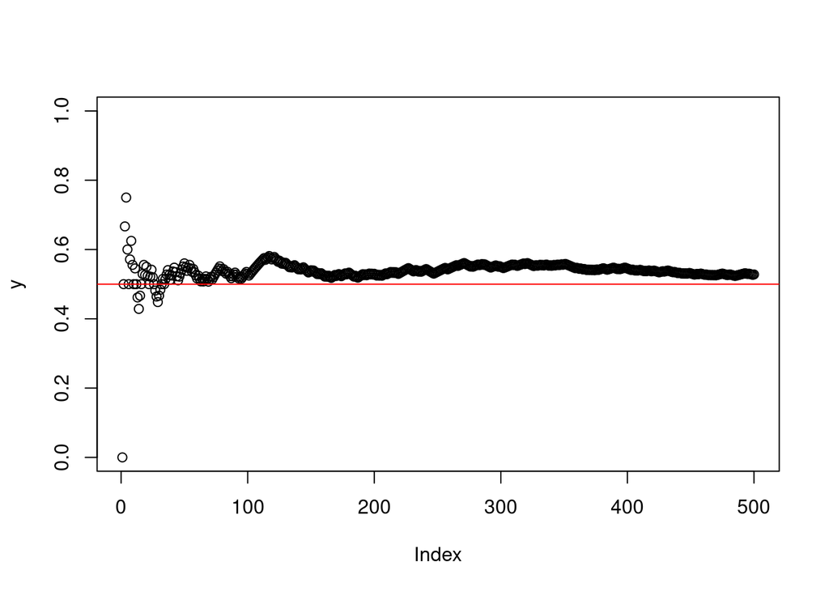

```r
N=500; p=0.5
x=sample(c(1,0), N, prob=c(p,1-p), rep=TRUE)
y=cumsum(x)/(1:N)
plot(y, ylim=c(0,1))
abline(p,0, col="red")
```

```r
print(mean(x))
```

```
## [1] 0.528
```

## 2.3 Variance

Just as we can calculate what the central tendency of an RV will have, we can also calculate the fluctuations around ist central tendeny. This is achieved by the variance $\mathbb{V}[X]$ of $X$. It is defined by

$$\begin{align}
\mathbb{V}[X] &:= \mathbb{E}[(X-\mathbb{E}[X])^2] \\ &\;=
\sum_{k\in\mathbb{Z}}(X_k-\mathbb{E}[X])^2\mathbb{P}(X=k) \\ &\;=
\mathbb{E}[X^2]-\mathbb{E}[X]^2
\end{align}$$

## 2.4 Exercises

1. A colleague of you who has unfortunately not the same stochastic knowledge as you do, turns to you for help. They tell you the expression of two genes of interest $g_1$ and $g_2$ with the following transcript abundance and according probabilities to observe these mRNA levels:

   $$\begin{align}
   &\mathbb{P}(G_1=100) = 0.2,\;\;\mathbb{P}(G_1= 300) =
   0.2,\;\;\mathbb{P}(G_1=5000) = 0.6 \\
   &\mathbb{P}(G_2=10) = 0.3,\;\;\mathbb{P}(G_2=250) =
   0.1,\;\;\mathbb{P}(G_2=1000) = 0.5,\;\;\mathbb{P}(G_2=10000) = 0.1
   \end{align}$$

   Since the two genes belong to the same gene family and have similar physiological functions, your colleague does not care so much about the expression levels he expects to see for the individual genes but wants to know the expected value of transcript abundance for both genes combined. He further tells you that the expression of both genes is independent from each other. Calculate the total amount of transcript he can expect to see.

   WARNING: In the definition made here, we used probabilities associated with the sample space in a rather informal way. Usually, when dealing with stochastics in a formal way, we need three things. First, the sample space $\Omega$ containing all possible outcomes of the experiment. Second, a $\sigma$-algebra or event space $\mathcal{F}$ is a collection of subsets of the sample space satisfying certain compatibility conditions. Last, we need a probability measure $\mathbb{P}$ that assigns to each event in the event space a probability. Putting all three together results in a so-called **probability space** or **probability triple** $(\Omega,\mathcal{F},\mathbb{P})$. However, we will not go deeper into the foundations of probability theory than we already did at that point and focus instead on the application. Just bear in mind that the definition of probabilities is usually baked right in the probability space together with the sample space and the event space.
2. Showing your colleague only the calculations, he does not believe you. Simulate a bunch of transcript abundance levels given the information above and convince him that math works and that he should finally start learning some basic stochastics.
3. Given the definition of $\mathbb{V}[X]$, show that $\mathbb{V}[X]=\mathbb{E}[X^2]-\mathbb{E}[X]^2$.
4. Simulate throws of two dice with increasing sample size. What is the expected value of the sum of the numbers? What happens to the mean value, as you increase the sample size? Plot the mean value against the sample size as well as the difference between mean value and expectation against the sample size. What do you see and why do you see that?

# 3 Discrete probability distributions

By now, we have defined the probabilities that $X$ attains the value $k$ for different scenarios multiple times by hand. Many real world experiments, which may be described by very different functions $X$, may however lead to the same probabilities $\mathbb P[X=k]$. It is thus relevant to focus on the underlying probabilities. They define the so-called *probability distribution* of $X$. For a discrete RV, it is determined by its *probability mass function* (PMF), which assigns to each value of $X$ its probability. Thus the PMF is the map $k\mapsto p_k=\mathbb{P}[X=k]$ for integer $k$. This is a powerful observation, because it means we are capable to describe very different experiments using very similar and sometimes quite simple mathematical constructs. We note that every function $f:\mathbb Z\to [0,1]$ such that $\sum_{k\in \mathbb Z} f(k)=1$ is a probability mass function.

## 3.1 Distributions in R

Since R was written specifically for statistical programming, it is not surprising that we have a plethora of commands that help us understand, investigate and simulate different distributions. For most distributions (I take as example for now the binomial distribution which will be defined a further down), these commands look as follows:

- `dbinom(k, size, prob, log = FALSE)`
  - for a given number $n$ of trials, and a given probability of success in each trial (prob), this command returns the value $\mathbb{P}[X=k]$ for all input values of $k$.
- `pbinom(t, size, prob, lower.tail = TRUE, log.p = FALSE)`
  - using almost the same parameters as above, this command returns the value of the cumulative distribution function (CDF) $F(t)=\mathbb{P}[X\leq t]$ for any given value $t$.
- `qbinom(p, size, prob, lower.tail = TRUE, log.p = FALSE)`
  - This command returns the so-called smallest $p$-quantile of a binomial distribution, given the parameters.
  - Specifically, the command gives the value $Q(p)=\min\{t: F(t)\ge p\}$. The function $p\mapsto Q(p)$ can be understood as the generalised inverse function of $F$.
- `rbinom(n, size, prob)`
  - This command samples values from a binomial distribution, where `n` is the number of experiments to perform, `size` is the number of trials in each experiment and `prob` is defined as above. This command is the most important one for simulating realizations of RVs from a given distribution.

Not all distributions depend on the same parameters. To check out what parameters each distribution function expects, just look up the help function for the desired distribution, e.g. `?dbinom` or `?dgeom`.

## 3.2 Bernoulli process

A number of interesting distributions arises from independent repeated tossing of a coin (which might be unfair).

Throwing a single coin is described by the Bernoulli distribution $Ber(p)$. If we have an independent sequence of RVs $(X_i)_{i\in\mathbb{N}}$ with $\mathbb{P}[X_i=1]=p$ and $\mathbb{P}[X_i=0]=1-p$ for all $i \in \mathbb{N}$, we say $X_i$ is distributed as $Ber(p)$ and we call $(X_i)_{i\in\mathbb{N}}$ a Bernouille process.

In R, it can be modeled using the formula of the binomial distribution and the right parameters:

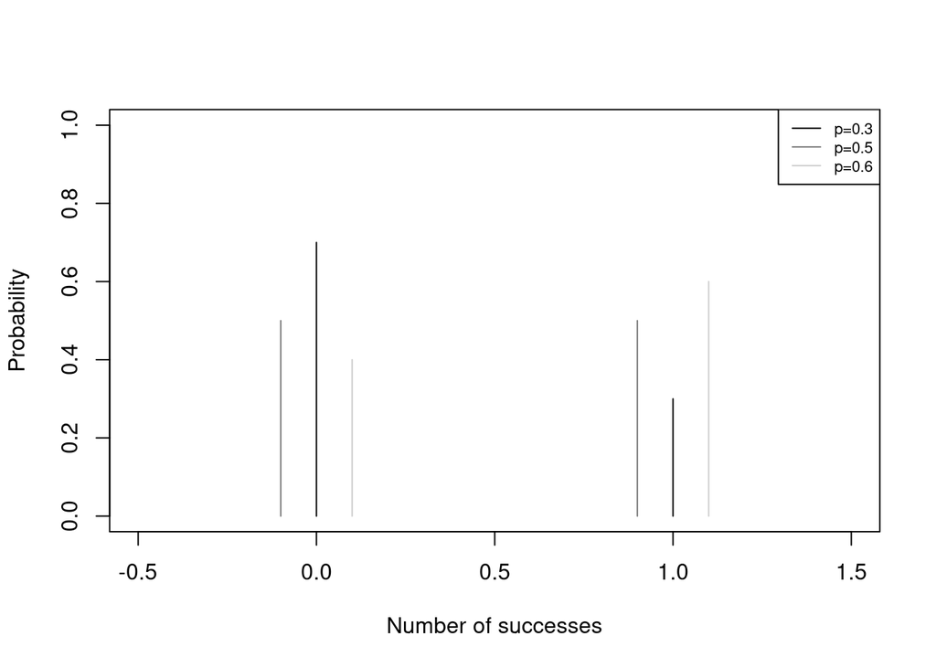

```r
x_values <- 0:1
plot(x_values, dbinom(x=x_values, size = 1, prob = 0.3), col='black', type = 'h',
     xlab = "Number of successes", ylab = 'Probability', xlim = c(-0.5,1.5), ylim=c(0,1))
points(x_values-0.1, dbinom(x=x_values, size = 1, prob = 0.5), col='#777777', type = 'h')
points(x_values+0.1, dbinom(x=x_values, size = 1, prob = 0.6), col='#CCCCCC', type = 'h')

# Add a legend
legend('topright', legend = c("p=0.3", "p=0.5", "p=0.6"),
       col = c("black", "#777777", "#CCCCCC"), lty = 1, cex = 0.7)
```

It is also clear from the definition of expectation and variance that $\mathbb{E}[X]=p$ and $\mathbb{V}[X]=p(1-p)$.

## 3.3 Binomial distribution

The binomial distribution $B(n,p)$ describes the distribution of **probabilities that we observe $k$ successes in $n$ trials**. If $X$ is distributed as $B(n,p)$, we have

$$\begin{align}
\mathbb{P}[X=k] &= \binom{n}{k}p^k(1-p)^{n-k} \\
\mathbb{E}[X] &= np \\
\mathbb{V}[X] &= np(1-p)
\end{align}$$

This PMF will readily tell us the probability that a coin lands one, two, or a dozen times head up, given $n$ total coin tosses and $p$ being the probability that the coin lands head up (or showing the side encoded by 1) in every independent coin toss.

The formula for the expectation and variance are clear, as $X$ is the sum of $n$ independent coin tosses and we have seen in the lecture that if $\mathbb{E}[X_i]$ is absolutely convergent for all $i \in 1,...,n$, we have $\mathbb{E}[X_1 + ...+X_n]$ = $\mathbb{E}[X_1] + ... + \mathbb{E}[X_n]$.

In R, it looks like follows for different values of $p$ and $n$:

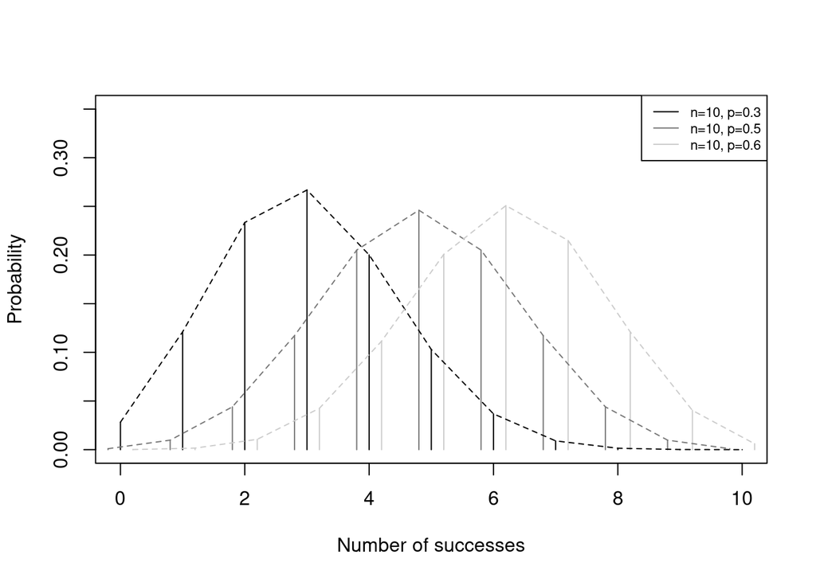

```r
x_values <- 0:10
plot(x_values, dbinom(x=x_values, size = 10, prob = 0.3), col='black', type = 'h',
     ylim = c(0,0.35),
     xlab = "Number of successes", ylab = 'Probability')
points(x_values-0.2, dbinom(x=x_values, size = 10, prob = 0.5), col='#777777', type = 'h')
points(x_values+0.2, dbinom(x=x_values, size = 10, prob = 0.6), col='#CCCCCC', type = 'h')

# Add lines for visuals
lines(x_values, dbinom(x=x_values, size = 10, prob = 0.3), col='black', lty=2)
lines(x_values-0.2, dbinom(x=x_values, size = 10, prob = 0.5), col='#777777', lty=2)
lines(x_values+0.2, dbinom(x=x_values, size = 10, prob = 0.6), col='#CCCCCC', lty=2)

# Add a legend
legend('topright', legend = c("n=10, p=0.3", "n=10, p=0.5", "n=10, p=0.6"),
       col = c("black", "#777777", "#CCCCCC"), lty = 1, cex = 0.7)
```

In reality, whenever you have a process with only two outcomes and a fixed probability, you can model the number that a specific outcome appears using the binomial distribution distribution. Some examples are:

- Given the probability $p$ that any plant dies during my experiment, how likely is it that all plants die?
- Given the probability $p$ to be involved in a street accident any given time I leave the house, how likely is it that I won’t be involved in an accident when I go to work every workday for one year straight?

## 3.4 Geometric distribution

The *geometric distribution* $Geo(p)$ gives us **the probability of the number of times a Bernoulli process that has to take place until the first success appears**, e.g. the first time head shows up in a coin toss. If $X$ is distributed as $Geo(p)$, we have for $k\in \mathbb N$ that:

$$\begin{align}
\mathbb{P}[X=k] &= p(1-p)^{k-1} \\
\mathbb{E}[X] &= \frac{1}{p} \\
\mathbb{V}[X] &= \frac{1-p}{p^2}
\end{align}$$

If you like video games, here is a good example for a geometric distribution:

- Some video game bosses are famously hard to beat. Given a probability $p$ to beat Sister Friede from Dark Souls 3 at any try (speaking from experience, $p$ is quite small in this case), what are the probabilities that a player beats her at the first, second, third try and so on?

Here is how the geometric distribution looks in R:

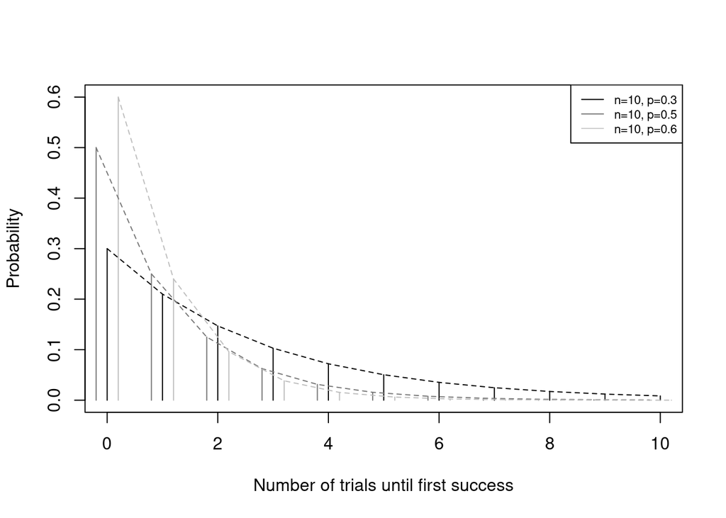

```r
x_values <- 0:10
plot(x_values, dgeom(x=x_values, prob = 0.3), col='black', type = 'h', ylim = c(0,0.6),
     xlab = "Number of trials until first success", ylab = 'Probability')
points(x_values-0.2, dgeom(x=x_values, prob = 0.5), col='#777777', type = 'h')
points(x_values+0.2, dgeom(x=x_values, prob = 0.6), col='grey', type = 'h')

# Add lines for visuals
lines(x_values, dgeom(x=x_values, prob = 0.3), col='black', lty=2)
lines(x_values-0.2, dgeom(x=x_values, prob = 0.5), col='#777777', lty=2)
lines(x_values+0.2, dgeom(x=x_values, prob = 0.6), col='grey', lty=2)

# Add a legend
legend('topright', legend = c("n=10, p=0.3", "n=10, p=0.5", "n=10, p=0.6"),
       col = c("black", "#777777", "#CCCCCC"), lty = 1, cex = 0.7)
```

## 3.5 Negative binomial distribution

This PMF tells us the **probability of the number of trials $k$ that occur until the $r^{th}$ success happens.** It is denoted by $NB(r,p)$. If $X$ is distributed as $NB(r,p)$, we have for $k\in \mathbb N$

$$\begin{align}
\mathbb{P}[X=k] &= \binom{k-1}{r-1}p^r(1-p)^{k-r} \\
\mathbb{E}[X] &= \frac{r}{p} \\
\mathbb{V}[X] &= \frac{r(1-p)}{p^2}
\end{align}$$

**Note that these probabilities are zero if $k$ is less than $r$**. For this reason, people sometimes consider instead the random quantity number of failures that occur until the $r^{th}$ success happens. The corresponding probabilities are obtained by replacing $k$ by $k+r$ in the above formula on the right hand side. The latter distribution is also called the negative binomial distribution, and it is implemented in R. It looks like follows for different values of $r$ and $p$:

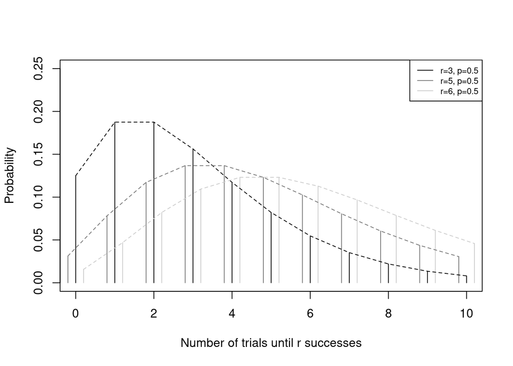

```r
# Calculate probabilities of the negative binomial distribution
# given k (x) n (size) and the P(X=1) (prob)
x_values <- 0:10
plot(x_values, dnbinom(x=x_values, size = 3, prob = 0.5), col='black', type = 'h', ylim = c(0,0.25),
     xlab = "Number of trials until r successes", ylab = 'Probability')
points(x_values-0.2, dnbinom(x=x_values, size = 5, prob = 0.5), col='#777777', type = 'h')
points(x_values+0.2, dnbinom(x=x_values, size = 6, prob = 0.5), col='#CCCCCC', type = 'h')

# Add lines for visuals
lines(x_values, dnbinom(x=x_values, size = 3, prob = 0.5), col='black', lty=2)
lines(x_values-0.2, dnbinom(x=x_values, size = 5, prob = 0.5), col='#777777', lty=2)
lines(x_values+0.2, dnbinom(x=x_values, size = 6, prob = 0.5), col='#CCCCCC', lty=2)
# Add a legend
legend('topright', legend = c("r=3, p=0.5", "r=5, p=0.5", "r=6, p=0.5"),
       col = c("black", "#777777", "#CCCCCC"), lty = 1, cex = 0.7)
```

Examples in biological context could be:

- The number of unsuccessful pollination events until $r$ flowers are successfully pollinated
- The number of contacts an infected person has until they infect $r$ persons.

## 3.6 Poisson distribution

The *Poisson distribution* $Poi(\lambda)$ is related to the Poisson process, as discussed in the lecture. It describes the probability that $k$ events happen in a fixed interval. For example, such an interval can be many things like a time span, the length of a molecule or an area. Its application stretches to all almost all areas of science, law and engineering. The $\lambda$ parameter models the average number of events that happen within an interval. In experimental situations where we deal with “rare events”, a Poisson process is a good model. If $X$ is distributed as $Poi(\lambda)$, we then have for $k\in\mathbb N_0$ that

$$\begin{align}
\mathbb{P}[X=k] &= e^{-\lambda}\frac{\lambda^k}{k!} \\
\mathbb{E}[X] &= \lambda \\
\mathbb{V}[X] &= \lambda
\end{align}$$

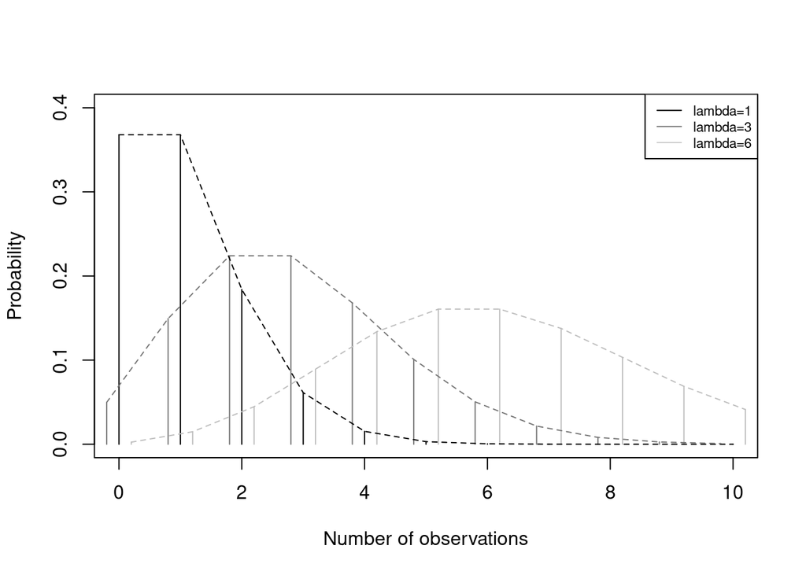

```r
x_values <- 0:10
plot(x_values, dpois(x=x_values, lambda = 1), col='black', type = 'h', ylim = c(0,0.4),
     xlab = "Number of observations", ylab = 'Probability')
points(x_values-0.2, dpois(x=x_values, lambda = 3), col='#777777', type = 'h')
points(x_values+0.2, dpois(x=x_values, lambda = 6), col='grey', type = 'h')

# Add lines for visuals
lines(x_values, dpois(x=x_values, lambda = 1), col='black', lty=2)
lines(x_values-0.2, dpois(x=x_values, lambda = 3), col='#777777', lty=2)
lines(x_values+0.2, dpois(x=x_values, lambda = 6), col='grey', lty=2)
# Add a legend
legend('topright', legend = c("lambda=1", "lambda=3", "lambda=6"),
       col = c("black", "#777777", "#CCCCCC"), lty = 1, cex = 0.7)
```

Some examples of phenomena that may be modeled using a Poisson distribution include:

- The number of chewing gums on a sidewalk tile
- The number of mutations occurring in a DNA segment of fixed length
- The number of photons hitting a detector

The Poisson distribution $Poi(np)$ may also be viewed as an approximation to the binomial distribution $B(n,p)$ for small $p$. This is explained in the micro-primer on stochastic calculus. You will prove a corresponding statement in “Stochastische Modellbildung”.

A good approximation may be given when $p\leq0.05$, $n\geq20$ and $np\leq10$:

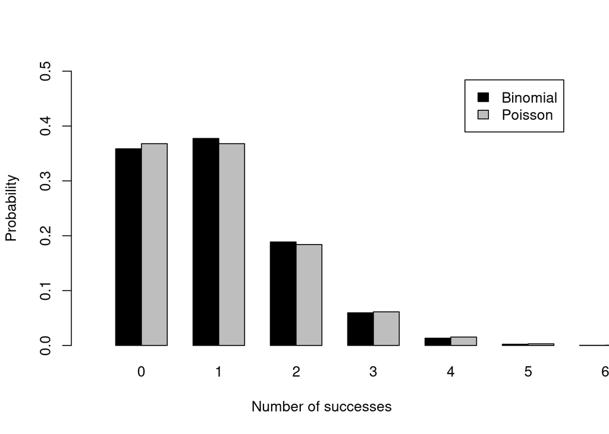

```r
# Define fitting parameters
n <- 20; p <- 0.05; lamb <- n*p
x <- dbinom(0:n, size = n, prob = p)
y <- dpois(0:n, lambda = lamb)
barplot(rbind(x, y), beside=TRUE, col=c('black', 'grey'),
        names.arg = 0:n,
        xlim = c(0,18),
        ylim = c(0,0.5),
        xlab = 'Number of successes', ylab = 'Probability',
        legend.text = c('Binomial', 'Poisson'))
```

Keep also in mind that the Poisson distribution will be important later on when we analyze simulated and real BLAST results.

## 3.7 Exercises

1. For your experiment, you sent a DNA sample to a sequence provider. You obtain 100,000 DNA sequences, each of length 1000. Together with the data, you are provided with the probability $p$ that any given base has been called erroneously. Now you want to know how many erroneous bases you can expect in each sequence and what the probability is to have any number of errors in a sequence from 0 to 1000.

   TIP: At first, this seems like a hard problem. However, one part of the course is for you to learn how to break down complex problems into smaller, more manageable ones. Below I have outlined several smaller tasks that take you step-by-step to the solution of the problem described above.

   1.1. Instead of simulating 100,000 reads from the start, try first to simulate a single DNA sequence using the `sample` function (remember to check out the help page of the function by typing `?sample`). Also, an important piece of insight is that we don’t really need the actual DNA sequence. We only need to distinguish between bases being called correctly or not. What kind of probabilistic process that you have already seen could be used to simulate a string of length 1000 where each position takes only one of two values (right or wrong call) with the probability of a wrong call at any position being defined as $p$? For $p$, use a value of your choice between $p=0.001$ and $p=0.005$ for this simulation. After sucessfully simulating the sequence, count the number of errors in the sequence. There is actually a very easy way to do this in R, if you think about it a little.

   1.2. After you have successfully simulated a single read, now you can scale up and simulate 100,000 in a row. This is not that much of a problem, you only need to think about how you can apply the approach of task 1.1. 100,000 times. We have already learned a coding principle that can be used for solving the task. Also, don’t forget to count the number of errors in each sequence. In the end, you should have a vector of 100,000 values (the number of simulated sequences), where each element is the number of errors in the corresponding sequence and there lies somewhere between 0 and 1000, corresponding with 0 bases or all bases being called erroneously, respectively.

   1.3. Plot the number of errors per sequence against the sequence length. Which probability distribution would you use to model the number of errors in a sequence. What parameters for the distribution should be used to model the outcome correctly?

   1.4. According to the distribution you used, what is the probability that a sequence contains no error at all? Is this number similar to the fraction of error-free sequences in your simulation?

   1.5. Given the results above, would you say quality control and cleaning of the obtained raw sequences is necessary for subsequent analyses?
2. You are offered to play a game. It goes like this: First, you pay an initial fee in order to play. Then, a fair coin is thrown. The initial prize is two Euro. If the coin shows head, the prize is doubled. If the coin shows tail, the game ends and you win the prize. Here are a few examples:
   - T: You win 2 Euro
   - HT: You win 4 Euro
   - HHT: You win 8 Euro
   - HHHT: You win 16 Euro
   - HHHHHHHT: You win 256 Euro

   You can repeatedly play the game as many times as you like, but you have to pay the fee each time you play. Now the interesting question. How much are you willing to pay in order to play the game? Is there a break-even point (fee and average prize cancel each other) and if so, where is it?

   TIP: In order to decide how much you are willing to pay for each game, you need to know how much you can expect to win on average if you play many times. This is the expectation of the game.

   2.1. Try to derive mathematically the expectation of the game. Recall the formula for the expectation and use the examples given above to understand how any given prize is associated with its probability.

   2.2. Write a simulation that backs up your answer of the previous task 2.1. Like before, try to break down the problem into smaller ones.

   2.2.1. First, simulate a single round of the game. Like before, there is a little twist that makes your life easier once you know about it. We actually don’t need to keep track of each individual toss, **we only need to keep track of the number of tosses until the first time tail shows up**, because then the game is over. You have already seen a distribution that you can use to simulate that.

   2.2.2. After you have successfully simulated a single game, think about our goal. We want to know how much we can expect to win on average if we play many many times. Now is the time to take your single simulation and turn it into many. After each game, calculate the current average payoff. After many games, this average payoff should converge to the expectation of the game. Simulate up to 100,000 rounds of the game and plot how the average payoff develops over time. What do you see?
3. You are working as a Hiwi at the astronomy department of your university and have the task to analyze the occurrence of shooting stars over time, given different rates of occurrence ($r_1=1/h$, $r_2=6/h$, $r_3=100/h$) at different locations $l_1$, $l_2$ and $l_3$, respectively. Try to answer the following questions using all the knowledge and skills you obtained so far:

   3.1. A night lasts 8 hours. What is the average number of shooting stars you ought to see within a single night at all three locations? Can you give a reasonable justification for your calculation like the expectation of a distribution or a simulation?

   3.2. How likely is it to see more than 10, 50, and 750 shooting stars at the locations $l_1$, $l_2$ and $l_3$, respectively? Hint: The `p` function of the right distribution will help you here.

# 4 Statistical Inference

Consider a stochastic experiment, where you do not know the underlying random mechanism. Statistical inference is the process of reconstructing the underlying random mechanism from repeated measurements. As a consequence of the strong law of large numbers, this would be possible if you had an infinite and typical data sample.

## 4.1 Empirical variance

We have argued above that the expectation of a random variable (if it exists and if it is finite), can be estimated from the arithmetic mean of a sample. The same idea works for the variance:

Let $(X_i)_{i\in \mathbb N}$ be an infinite sequence of independent, identically distributed random variables, whose expectation $\mathbb{E}[X_1]$ exists and is finite. We then have almost surely

$$\frac{1}{N-1} \sum_{i=1}^N (X_i - \overline{X}_N)^2\to \mathbb V[X_1]
\qquad (N\to \infty)$$

The random variable on the left hand side is called the empirical variance of the sample $X_1, \ldots, X_N$.

## 4.2 interval probabilities

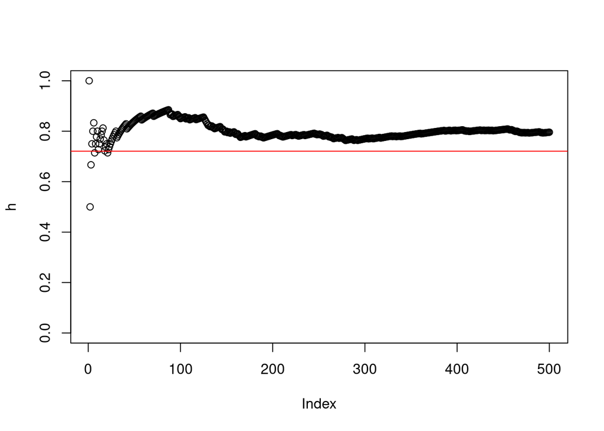

```r
n=100; p=0.3
b=35; a=25
# compute the probability $P(X\in (a,b])$
pab= pbinom(b,n,p)-pbinom(a,n,p)
# set sample size
N=500
# perform repeated experiment
x= rbinom(N,n,p)
# get absolute freqeuncies
H = ((x >= a) & (x <= b))
# compute relative frequencies
h=cumsum(H)/(1:N)
plot(h, ylim=c(0,1))
abline(pab,0, col="red")
```

## 4.3 cumulative distribution function

$$t\mapsto F_{X_1,\ldots, X_N}(t)=\frac{1}{N} \sum_{i=1}^N
1_{(-\infty,t]}(X_i)$$
converges to $F(t)=\mathbb P(X\le t)$ almost surely, as $N\to \infty$.

We can visualize this statement as follows.

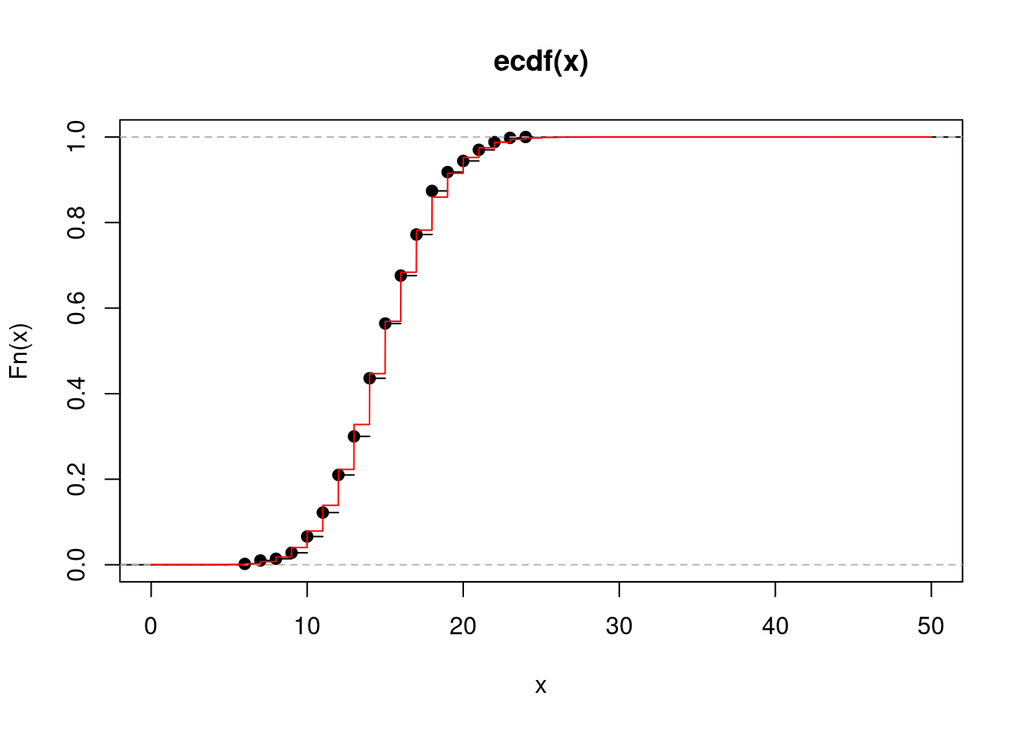

```r
n=50; p=0.3
N=500
# generate sample of size N
x=rbinom(N,n,p)
# plot ecdf of sample
plot(ecdf(x), xlim=c(0,n), ylim=c(0,1))
# plot CDF with high numerical resolution n
# otherwise the steps of the CDF will be blurred
curve(pbinom(x,n,p), add=TRUE, col="red", n=5000)
```

## 4.4 estimation error

In general, it will not be possible to reconstruct the underlying random mechanism to arbitrary precision, since you only have a finite sample at hand, which might not be typical.

A simple rule of thumb for the estimation error on the cumulative distribution function is obtained in a way similar to that of the arithmetic mean above.

If you would repeatedly estimate the unknown $F(t)$ from random numbers $x_1,\ldots, x_N$ by the number $F_{x_1, \ldots, x_N}(t)$, you would have for at least $99.9\%$ of these estimates the error bound

$$\Big|F_{x_1, \ldots, x_N}(t)-F(t)\Big| \le \frac{2}{\sqrt{N}} \ .$$

You may visualize the approximation error as follows:

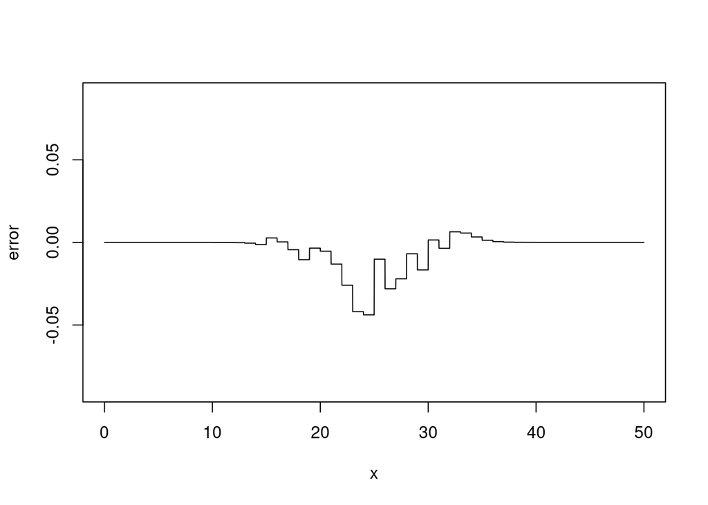

```r
n=50; p=0.5
N=500
# generate sample of size N
x=rbinom(N,n,p)
# define error function
error=function(t) ecdf(x)(t)-pbinom(t,n,p)
plot(error, xlim=c(0,n), n=5000, ylim=c(-2/sqrt(N), 2/sqrt(N)))
```